# rvest

Sampo Suzuki

2018-12-06

# ポケモンGO

[【ポケモンGO】最強ポケモンランキング【11/30最新版】](https://appmedia.jp/pokemon_go/350150)

## Rank SS

```r
(rank_ss <- site_html %>%
  rvest::html_node(xpath = xpath_ss) %>%
  rvest::html_table() %>%
  dplyr::mutate(rank = "SS") %>%
  tidyr::separate(`ポケモン`, into = c("name", "memo", "memo2")) %>%
  dplyr::mutate(memo2 = dplyr::if_else(name == "アローラ", name, memo2),
                name = dplyr::if_else(name == "アローラ", memo, name),
                name = dplyr::if_else(!is.na(memo2),
                                      paste(name, "（", memo2, "の姿）", sep = ""),
                                      name),
                memo = dplyr::if_else(!is.na(memo2), memo2, memo)) %>%
  dplyr::select(rank, name, type = `タイプ`, memo, CP = `最大CP`,
                skill = `おすすめわざ`) %>%
  tidyr::separate(skill, c("skill", "type1", "skill1", "type2", "skill2"),
                  sep = "([【】])") %>%
  dplyr::select(-skill)) %>%
  DT::datatable()
```

|  | rank | name | type | memo | CP | type1 | skill1 | type2 | skill2 |
| --- | --- | --- | --- | --- | --- | --- | --- | --- | --- |
| 1 | SS | ミュウツー | エスパー |  | 4178 | エスパータイプ | サイコカッターサイコキネシス | 対ノーマル・あく | サイコカッターきあいだま |
| 2 | SS | バンギラス | いわあく |  | 3835 | あくタイプ | かみつくかみくだく | コミュニティデイ限定 | うちおとすストーンエッジ |
| 3 | SS | カイリキー | かくとう |  | 3056 | かくとうタイプ | カウンターばくれつパンチ |  |  |
| 4 | SS | カイオーガ | みず |  | 4115 | みずタイプ | たきのぼりハイドロポンプ |  |  |
| 5 | SS | レックウザ | ドラゴンひこう |  | 3835 | ドラゴンタイプ | ドラゴンテールげきりん | ひこうタイプ | エアスラッシュつばめがえし |
| 6 | SS | ライコウ | でんき |  | 3452 | でんきタイプ | でんきショックワイルドボルト |  |  |
| 7 | SS | サンダー | でんきひこう |  | 3527 | サンダーデイ限定 | でんきショックでんじほう | でんきタイプ | チャージビームでんじほう |
| 8 | SS | ファイヤー | ほのおひこう |  | 3465 | ほのおタイプ | ほのおのうずオーバーヒート | 強風ブースト時 | ほのおのうずゴッドバード |
| 9 | SS | カイリュー | ひこうドラゴン |  | 3792 | ドラゴンタイプ | ドラゴンテールりゅうせいぐん |  |  |
| 10 | SS | グラードン | じめん |  | 4115 | じめんタイプ | マッドショットじしん |  |  |

[output cut: 1 more lines]

## Rank S

```r
(rank_s <- site_html %>%
  rvest::html_node(xpath = xpath_s) %>%
  rvest::html_table() %>%
  dplyr::mutate(rank = "S") %>%
  tidyr::separate(`ポケモン`, into = c("name", "memo", "memo2")) %>%
  dplyr::mutate(memo2 = dplyr::if_else(name == "アローラ", name, memo2),
                name = dplyr::if_else(name == "アローラ", memo, name),
                name = dplyr::if_else(!is.na(memo2),
                                      paste(name, "（", memo2, "の姿）", sep = ""),
                                      name),
                memo = dplyr::if_else(!is.na(memo2), memo2, memo)) %>%
  dplyr::select(rank, name, type = `タイプ`, memo, CP = `最大CP`,
                skill = `おすすめわざ`) %>%
  tidyr::separate(skill, c("skill", "type1", "skill1", "type2", "skill2"),
                  sep = "([【】])") %>%
  dplyr::select(-skill)) %>%
  DT::datatable()
```

|  | rank | name | type | memo | CP | type1 | skill1 | type2 | skill2 |
| --- | --- | --- | --- | --- | --- | --- | --- | --- | --- |
| 1 | S | ドサイドン | じめんいわ |  | 3733 | しめんタイプ | どろかけじしん | いわタイプ | うちおとすストーンエッジ |
| 2 | S | ハッサム | むしはがね |  | 3001 | はがねタイプ | バレットパンチアイアンヘッド | むしタイプ | れんぞくぎりシザークロス |
| 3 | S | ラティオス | ドラゴンエスパー |  | 3812 | ドラゴンタイプ | りゅうのいぶきドラゴンクロー | エスパータイプ | しねんのずつきサイコキネシス |
| 4 | S | エンテイ | ほのお |  | 3473 | ほのおタイプ | ほのおのうずオーバーヒート |  |  |
| 5 | S | ルギア | エスパーひこう |  | 3703 | エスパータイプ | じんつうりきみらいよち |  |  |
| 6 | S | ボーマンダ | ドラゴンひこう |  | 3749 | ドラゴンタイプ | ドラゴンテールりゅうせいぐん |  |  |
| 7 | S | フリーザー | こおりひこう |  | 3051 | こおりタイプ | こおりのいぶきふぶき |  |  |
| 8 | S | ゲンガー | ゴーストどく |  | 2878 | ゴーストタイプ | たたりめシャドーボール |  |  |
| 9 | S | フーディン | エスパー |  | 3057 | エスパータイプ | ねんりきみらいよち |  |  |
| 10 | S | サーナイト | エスパーフェアリー |  | 3093 | エスパータイプ | ねんりきサイコキネシス | 防衛 | ねんりきマジカルシャイン |

[output cut: 1 more lines]

## Rank A+

```r
(rank_ap <- site_html %>%
  rvest::html_node(xpath = xpath_ap) %>%
  rvest::html_table() %>%
  dplyr::mutate(rank = "A+") %>%
  tidyr::separate(`ポケモン`, into = c("name", "memo", "memo2")) %>%
  dplyr::mutate(memo2 = dplyr::if_else(name == "アローラ", name, memo2),
                name = dplyr::if_else(name == "アローラ", memo, name),
                name = dplyr::if_else(!is.na(memo2),
                                      paste(name, "（", memo2, "の姿）", sep = ""),
                                      name),
                memo = dplyr::if_else(!is.na(memo2), memo2, memo)) %>%
  dplyr::select(rank, name, type = `タイプ`, memo, CP = `最大CP`,
                skill = `おすすめわざ`) %>%
  tidyr::separate(skill, c("skill", "type1", "skill1", "type2", "skill2"),
                  sep = "([【】])") %>%
  dplyr::select(-skill)) %>%
  DT::datatable()
```

|  | rank | name | type | memo | CP | type1 | skill1 | type2 | skill2 |
| --- | --- | --- | --- | --- | --- | --- | --- | --- | --- |
| 1 | A+ | ホウオウ | ほのおひこう |  | 3863 | ダメージ効率 | はがねのつばさだいもんじ | かくとう対策 | じんつうりきブレイブバード |
| 2 | A+ | デオキシス | エスパー | 耐久に難あり | 3160 | エスパータイプ | しねんのずつきサイコブースト |  |  |
| 3 | A+ | カビゴン | ノーマル | 防衛のみ | 3225 | 攻撃 | したでなめるはかいこうせん | 防衛 | しねんのずつきはかいこうせん |
| 4 | A+ | ブースター | ほのお |  | 3029 | ほのおタイプ | ほのおのうずオーバーヒート |  |  |
| 5 | A+ | ギャラドス | みずひこう |  | 3391 | みずタイプ | たきのぼりハイドロポンプ |  |  |
| 6 | A+ | ラティアス | ドラゴンエスパー |  | 3510 | ドラゴンタイプ | りゅうのいぶきげきりん | エスパータイプ | しねんのずつきサイコキネシス |
| 7 | A+ | フシギバナ | くさどく |  | 2720 | コミュニティデイ限定 | つるのむちハードプラント |  |  |
| 8 | A+ | シャワーズ | みず |  | 3114 | みずタイプ | みずでっぽうハイドロポンプ |  |  |
| 9 | A+ | ナッシー | くさエスパー |  | 3078 | くさタイプ | タネマシンガンソーラービーム |  |  |
| 10 | A+ | ハピナス | ノーマル | 防衛のみ | 2757 | 攻撃 | はたくはかいこうせん | 防衛 | しねんのずつきマジカルシャイン |

[output cut: 12 more lines]

## Rank A

```r
(rank_a <- site_html %>%
  rvest::html_node(xpath = xpath_a) %>%
  rvest::html_table() %>%
  dplyr::mutate(rank = "A") %>%
  tidyr::separate(`ポケモン`, into = c("name", "memo", "memo2")) %>%
  dplyr::mutate(memo2 = dplyr::if_else(name == "アローラ", name, memo2),
                name = dplyr::if_else(name == "アローラ", memo, name),
                name = dplyr::if_else(!is.na(memo2),
                                      paste(name, "（", memo2, "の姿）", sep = ""),
                                      name),
                memo = dplyr::if_else(!is.na(memo2), memo2, memo)) %>%
  dplyr::select(rank, name, type = `タイプ`, memo, CP = `最大CP`,
                skill = `おすすめわざ`) %>%
  tidyr::separate(skill, c("skill", "type1", "skill1", "type2", "skill2"),
                  sep = "([【】])") %>%
  dplyr::select(-skill)) %>%
  DT::datatable()
```

|  | rank | name | type | memo | CP | type1 | skill1 | type2 | skill2 |
| --- | --- | --- | --- | --- | --- | --- | --- | --- | --- |
| 1 | A | ルカリオ | かくとうはがね |  | 2703 | かくとうタイプ | カウンターインファイト |  |  |
| 2 | A | デンリュウ | でんき |  | 2852 | でんきタイプ | ボルトチェンジかみなり |  |  |
| 3 | A | スイクン | みず |  | 2983 | みずタイプ | じんつうりきめざめるパワー(みず)ハイドロポンプ |  |  |
| 4 | A | エンペルト | みずはがね |  | 2900 | みずタイプ | たきのぼりハイドロポンプ | はがねタイプ | メタルクローラスターカノン |
| 5 | A | ゴウカザル | ほのおかくとう |  | 2683 | ほのおタイプ | ほのおのうずかえんほうしゃ |  |  |
| 6 | A | レジスチル | はがね |  | 2447 | はがねタイプ | メタルクローラスターカノン |  |  |
| 7 | A | ウインディ | ほのお |  | 3029 | ほのおタイプ | ほのおのキバだいもんじ |  |  |
| 8 | A | ドンファン | じめん |  | 3013 |  |  |  |  |
| 9 | A | ドダイトス | くさじめん |  | 2934 | くさタイプ | はっぱカッターソーラービーム |  |  |
| 10 | A | オーダイル | みず |  | 2857 | みずタイプ | みずでっぽうハイドロポンプ |  |  |

[output cut: 3 more lines]

## Total

```r
(rank_all <- rank_ss %>%
  dplyr::bind_rows(rank_s, rank_ap, rank_a)) %>%
  DT::datatable()
```

|  | rank | name | type | memo | CP | type1 | skill1 | type2 | skill2 |
| --- | --- | --- | --- | --- | --- | --- | --- | --- | --- |
| 1 | SS | ミュウツー | エスパー |  | 4178 | エスパータイプ | サイコカッターサイコキネシス | 対ノーマル・あく | サイコカッターきあいだま |
| 2 | SS | バンギラス | いわあく |  | 3835 | あくタイプ | かみつくかみくだく | コミュニティデイ限定 | うちおとすストーンエッジ |
| 3 | SS | カイリキー | かくとう |  | 3056 | かくとうタイプ | カウンターばくれつパンチ |  |  |
| 4 | SS | カイオーガ | みず |  | 4115 | みずタイプ | たきのぼりハイドロポンプ |  |  |
| 5 | SS | レックウザ | ドラゴンひこう |  | 3835 | ドラゴンタイプ | ドラゴンテールげきりん | ひこうタイプ | エアスラッシュつばめがえし |
| 6 | SS | ライコウ | でんき |  | 3452 | でんきタイプ | でんきショックワイルドボルト |  |  |
| 7 | SS | サンダー | でんきひこう |  | 3527 | サンダーデイ限定 | でんきショックでんじほう | でんきタイプ | チャージビームでんじほう |
| 8 | SS | ファイヤー | ほのおひこう |  | 3465 | ほのおタイプ | ほのおのうずオーバーヒート | 強風ブースト時 | ほのおのうずゴッドバード |
| 9 | SS | カイリュー | ひこうドラゴン |  | 3792 | ドラゴンタイプ | ドラゴンテールりゅうせいぐん |  |  |
| 10 | SS | グラードン | じめん |  | 4115 | じめんタイプ | マッドショットじしん |  |  |

[output cut: 47 more lines]

## Cross Table

```r
cp_table <- rank_all %>%
  dplyr::group_by(type) %>%
  dplyr::summarise(CP = round(max(CP)))

rank_all %>%
  dplyr::count(rank, type) %>%
  tidyr::spread(key = rank, value = n) %>%
  dplyr::left_join(cp_table, .) %>%
  DT::datatable()
```

|  | type | CP | A | A+ | S | SS |
| --- | --- | --- | --- | --- | --- | --- |
| 1 | いわあく | 3835 |  |  |  | 1 |
| 2 | いわでんき | 2949 |  | 1 |  |  |
| 3 | かくとう | 3056 |  |  |  | 1 |
| 4 | かくとうはがね | 2703 | 1 |  |  |  |
| 5 | くさじめん | 2934 | 1 |  |  |  |
| 6 | くさどく | 2720 |  | 1 |  |  |
| 7 | くさエスパー | 3078 |  | 1 |  |  |
| 8 | こおり | 3122 |  | 1 |  |  |
| 9 | こおりひこう | 3051 |  |  | 1 |  |
| 10 | じめん | 4115 | 1 |  |  | 1 |

[output cut: 26 more lines]

## Heat Map

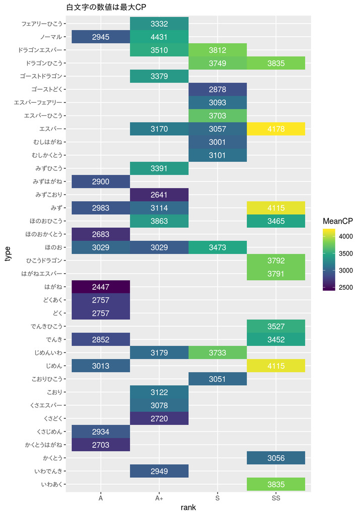

```r
rank_all %>%
  dplyr::group_by(type, rank) %>%
  dplyr::summarise(MaxCP = max(CP), MeanCP = round(mean(CP))) %>%
  ggplot2::ggplot(ggplot2::aes(x = rank, y = type)) +
    ggplot2::geom_tile(ggplot2::aes(fill = MeanCP)) +
    ggplot2::geom_text(ggplot2::aes(label = MaxCP), colour = "#FFFFFF") +
    ggplot2::scale_fill_continuous(type = "viridis") +
    ggplot2::labs(subtitle = "白文字の数値は最大CP")
```

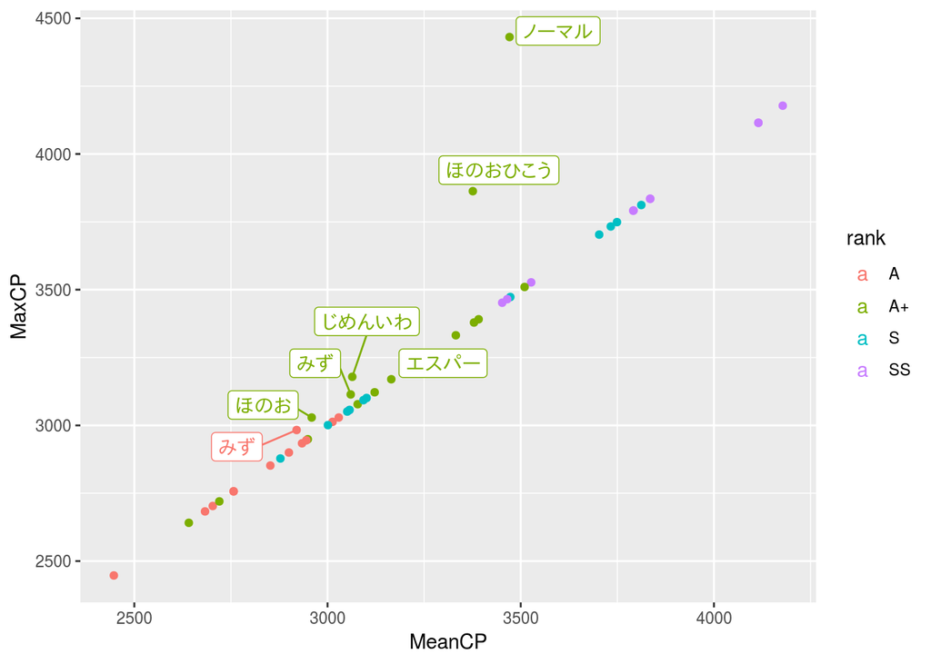

```r
rank_all %>%
  dplyr::group_by(type, rank) %>%
  dplyr::summarise(MaxCP = max(CP), MeanCP = round(mean(CP))) %>%
  dplyr::mutate(text = dplyr::case_when(MaxCP > MeanCP ~ type, TRUE ~ "")) %>%
  ggplot2::ggplot(ggplot2::aes(x = MeanCP, y = MaxCP)) +
    ggplot2::geom_point(ggplot2::aes(colour = rank)) +
    ggrepel::geom_label_repel(ggplot2::aes(label = text, colour = rank))
```

# プロ野球

[プロ野球順位表](https://baseball.yahoo.co.jp/npb/standings/)

## セ・リーグ

```r
site_html %>%
  rvest::html_node(xpath = xpath_ce) %>%
  rvest::html_table() %>%
  DT::datatable()
```

|  | Var.2 | Var.3 | 試合 | 勝利 | 敗戦 | 引分 | 勝率 | 勝差 | 残試合 | 得点 | 失点 | 本塁打 | 盗塁 | 打率 | 防御率 |
| --- | --- | --- | --- | --- | --- | --- | --- | --- | --- | --- | --- | --- | --- | --- | --- |
| 1 | 1位 | 広島 | 143 | 82 | 59 | 2 | 0.582 | 優勝 | 0 | 721 | 651 | 175 | 95 | 0.262 | 4.12 |
| 2 | 2位 | ヤクルト | 143 | 75 | 66 | 2 | 0.532 | 7 | 0 | 658 | 665 | 135 | 68 | 0.266 | 4.13 |
| 3 | 3位 | 巨人 | 143 | 67 | 71 | 5 | 0.486 | 6.5 | 0 | 625 | 575 | 152 | 61 | 0.257 | 3.79 |
| 4 | 4位 | ＤｅＮＡ | 143 | 67 | 74 | 2 | 0.475 | 1.5 | 0 | 572 | 642 | 181 | 71 | 0.25 | 4.18 |
| 5 | 5位 | 中日 | 143 | 63 | 78 | 2 | 0.447 | 4 | 0 | 598 | 654 | 97 | 61 | 0.265 | 4.36 |
| 6 | 6位 | 阪神 | 143 | 62 | 79 | 2 | 0.44 | 1 | 0 | 577 | 628 | 85 | 77 | 0.253 | 4.03 |

## パ・リーグ

```r
site_html %>%
  rvest::html_node(xpath = xpath_pa) %>%
  rvest::html_table() %>%
  DT::datatable()
```

|  | Var.2 | Var.3 | 試合 | 勝利 | 敗戦 | 引分 | 勝率 | 勝差 | 残試合 | 得点 | 失点 | 本塁打 | 盗塁 | 打率 | 防御率 |
| --- | --- | --- | --- | --- | --- | --- | --- | --- | --- | --- | --- | --- | --- | --- | --- |
| 1 | 1位 | 西武 | 143 | 88 | 53 | 2 | 0.624 | 優勝 | 0 | 792 | 653 | 196 | 132 | 0.273 | 4.24 |
| 2 | 2位 | ソフトバンク | 143 | 82 | 60 | 1 | 0.577 | 6.5 | 0 | 685 | 579 | 202 | 80 | 0.266 | 3.9 |
| 3 | 3位 | 日本ハム | 143 | 74 | 66 | 3 | 0.529 | 7 | 0 | 589 | 586 | 140 | 98 | 0.251 | 3.77 |
| 4 | 4位 | オリックス | 143 | 65 | 73 | 5 | 0.471 | 8 | 0 | 538 | 565 | 108 | 97 | 0.244 | 3.69 |
| 5 | 5位 | ロッテ | 143 | 59 | 81 | 3 | 0.421 | 7 | 0 | 534 | 628 | 78 | 124 | 0.247 | 4.04 |
| 6 | 6位 | 楽天 | 143 | 58 | 82 | 3 | 0.414 | 1 | 0 | 520 | 583 | 132 | 69 | 0.241 | 3.78 |

## 交流戦

```r
site_html %>%
  rvest::html_node(xpath = xpath_in) %>%
  rvest::html_table() %>%
  DT::datatable()
```

|  | Var.2 | Var.3 | 試合 | 勝利 | 敗戦 | 引分 | 勝率 | 勝差 | 残試合 | 得点 | 失点 | 本塁打 | 盗塁 | 打率 | 防御率 |
| --- | --- | --- | --- | --- | --- | --- | --- | --- | --- | --- | --- | --- | --- | --- | --- |
| 1 | 1位 | ヤクルト | 18 | 12 | 6 | 0 | 0.667 | - | 0 | 78 | 64 | 14 | 8 | 0.251 | 3.38 |
| 2 | 2位 | オリックス | 18 | 11 | 6 | 1 | 0.647 | 0.5 | 0 | 78 | 58 | 18 | 11 | 0.249 | 2.98 |
| 3 | 3位 | ロッテ | 18 | 11 | 7 | 0 | 0.611 | 0.5 | 0 | 59 | 49 | 7 | 17 | 0.278 | 2.4 |
| 4 | 4位 | ソフトバンク | 18 | 11 | 7 | 0 | 0.611 | 0 | 0 | 81 | 77 | 30 | 10 | 0.235 | 3.83 |
| 5 | 5位 | 日本ハム | 18 | 10 | 8 | 0 | 0.556 | 1 | 0 | 104 | 79 | 24 | 16 | 0.267 | 4.14 |
| 6 | 6位 | 西武 | 18 | 10 | 8 | 0 | 0.556 | 0 | 0 | 101 | 88 | 26 | 22 | 0.268 | 4.59 |
| 7 | 7位 | 巨人 | 18 | 8 | 10 | 0 | 0.444 | 2 | 0 | 66 | 59 | 20 | 9 | 0.248 | 3.13 |
| 8 | 8位 | ＤｅＮＡ | 18 | 8 | 10 | 0 | 0.444 | 0 | 0 | 62 | 81 | 20 | 13 | 0.241 | 4.33 |
| 9 | 9位 | 中日 | 18 | 7 | 11 | 0 | 0.389 | 1 | 0 | 67 | 88 | 12 | 7 | 0.26 | 4.95 |
| 10 | 10位 | 広島 | 18 | 7 | 11 | 0 | 0.389 | 0 | 0 | 77 | 104 | 19 | 8 | 0.26 | 5.6 |

[output cut: 2 more lines]

## オープン戦

```r
site_html %>%
  rvest::html_node(xpath = xpath_op) %>%
  rvest::html_table() %>%
  DT::datatable()
```

|  | Var.2 | Var.3 | 試合 | 勝利 | 敗戦 | 引分 | 勝率 | 勝差 | 得点 | 失点 | 本塁打 | 盗塁 | 打率 | 防御率 |
| --- | --- | --- | --- | --- | --- | --- | --- | --- | --- | --- | --- | --- | --- | --- |
| 1 | 1位 | 巨人 | 17 | 11 | 5 | 1 | 0.688 | - | 78 | 60 | 19 | 9 | 0.223 | 2.97 |
| 2 | 2位 | ロッテ | 14 | 8 | 4 | 2 | 0.667 | 1 | 62 | 57 | 3 | 19 | 0.279 | 3.6 |
| 3 | 3位 | 楽天 | 16 | 9 | 5 | 2 | 0.643 | 0 | 80 | 69 | 13 | 19 | 0.269 | 3.9 |
| 4 | 4位 | ＤｅＮＡ | 15 | 8 | 5 | 2 | 0.615 | 0.5 | 60 | 52 | 15 | 12 | 0.244 | 3.33 |
| 5 | 5位 | オリックス | 14 | 7 | 5 | 2 | 0.583 | 0.5 | 54 | 43 | 13 | 22 | 0.23 | 2.95 |
| 6 | 5位 | 日本ハム | 15 | 7 | 5 | 3 | 0.583 | 0 | 66 | 58 | 25 | 9 | 0.248 | 3.48 |
| 7 | 7位 | 西武 | 16 | 8 | 6 | 2 | 0.571 | 0 | 47 | 52 | 9 | 12 | 0.24 | 3.06 |
| 8 | 8位 | ヤクルト | 16 | 6 | 6 | 4 | 0.5 | 1 | 72 | 74 | 13 | 13 | 0.267 | 4.23 |
| 9 | 9位 | 中日 | 17 | 7 | 9 | 1 | 0.438 | 1 | 76 | 79 | 15 | 10 | 0.262 | 4.18 |
| 10 | 10位 | ソフトバンク | 16 | 5 | 10 | 1 | 0.333 | 1.5 | 64 | 66 | 20 | 16 | 0.249 | 3.83 |

[output cut: 2 more lines]

# 大相撲

[平成30年11月場所 取組結果](https://sports.yahoo.co.jp/sumo/torikumi/stats/?bashoId=201811)

## 幕内（中入り後）取組一覧

取組一覧のヘッダが“東”と“西”にまとめられているために「ヘッダなし」で読みこまないとその後のデータフレーム化処理でおかしくなる点に注意。

```r
df <- purrr::map2(site_url, c(1:15), ~ paste(.x, .y, sep = "")) %>%
  purrr::map2_df(c(1:15), .f = function(.x, .y) {
    xml2::read_html(.x) %>%
      rvest::xml_node(xpath = xpath_mu) %>%
      rvest::html_table(header = FALSE) %>%
      dplyr::slice(-1) %>%
      dplyr::mutate(day = .y)
    })

result <- df %>%
  tidyr::extract(X2, "e_name", regex = "([^[:digit:]]+)", remove = FALSE) %>%
  tidyr::extract(X6, "w_name", regex = "([^[:digit:]]+)", remove = FALSE) %>%
  tidyr::extract(X2, c("e_win", "e_lose"),
                 regex = "([[:digit:]]+)勝([[:digit:]]+)", remove = TRUE) %>%
  tidyr::extract(X6, c("w_win", "w_lose"),
                 regex = "([[:digit:]]+)勝([[:digit:]]+)", remove = TRUE) %>%
  dplyr::select(day, e_class = X1, e_name, e_win, e_lose, e_mark = X3,
                kimarite = X4, w_mark = X5, w_class = X7, w_name, w_win, w_lose)

result %>% DT::datatable()
```

|  | day | e_class | e_name | e_win | e_lose | e_mark | kimarite | w_mark | w_class | w_name | w_win | w_lose |
| --- | --- | --- | --- | --- | --- | --- | --- | --- | --- | --- | --- | --- |
| 1 | 1 | 東横綱 | 稀勢の里 | 0 | 1 | ● | はたき込み | ○ | 東小結 | 貴景勝 | 1 | 0 |
| 2 | 1 | 東大関 | 豪栄道 | 1 | 0 | ○ | 押し出し | ● | 西前筆 | 北勝富士 | 0 | 1 |
| 3 | 1 | 東前筆 | 妙義龍 | 0 | 1 | ● | 寄り切り | ○ | 西大関 | 高安 | 1 | 0 |
| 4 | 1 | 西前2 | 玉鷲 | 1 | 0 | ○ | 押し出し | ● | 西大関 | 栃ノ心 | 0 | 1 |
| 5 | 1 | 東関脇 | 御嶽海 | 0 | 1 | ● | 突き落とし | ○ | 東前2 | 栃煌山 | 1 | 0 |
| 6 | 1 | 東前3 | 錦木 | 0 | 1 | ● | 寄り切り | ○ | 西関脇 | 逸ノ城 | 1 | 0 |
| 7 | 1 | 東前4 | 正代 | 1 | 0 | ○ | 下手投げ | ● | 西前3 | 竜電 | 0 | 1 |
| 8 | 1 | 東前5 | 千代大龍 | 0 | 1 | ● | すくい投げ | ○ | 西前4 | 嘉風 | 1 | 0 |
| 9 | 1 | 東前6 | 貴ノ岩 | 0 | 1 | ● | 上手投げ | ○ | 西前5 | 朝乃山 | 1 | 0 |
| 10 | 1 | 東前7 | 阿炎 | 0 | 1 | ● | 押し出し | ○ | 西前6 | 輝 | 1 | 0 |

[output cut: 286 more lines]

## 十両取組一覧

```r
df <- purrr::map2(site_url, c(1:15), ~ paste(.x, .y, sep = "")) %>%
  purrr::map2_df(c(1:15), .f = function(.x, .y) {
    xml2::read_html(.x) %>%
      rvest::xml_node(xpath = xpath_ju) %>%
      rvest::html_table(header = FALSE) %>%
      dplyr::slice(-1) %>%
      dplyr::mutate(day = .y)})

result <- df %>%
  tidyr::extract(X2, "e_name", regex = "([^[:digit:]]+)", remove = FALSE) %>%
  tidyr::extract(X6, "w_name", regex = "([^[:digit:]]+)", remove = FALSE) %>%
  tidyr::extract(X2, c("e_win", "e_lose"),
                 regex = "([[:digit:]]+)勝([[:digit:]]+)", remove = TRUE) %>%
  tidyr::extract(X6, c("w_win", "w_lose"),
                 regex = "([[:digit:]]+)勝([[:digit:]]+)", remove = TRUE) %>%
  dplyr::select(day, e_class = X1, e_name, e_win, e_lose, e_mark = X3,
                kimarite = X4, w_mark = X5, w_class = X7, w_name, w_win, w_lose)

result %>% DT::datatable()
```

|  | day | e_class | e_name | e_win | e_lose | e_mark | kimarite | w_mark | w_class | w_name | w_win | w_lose |
| --- | --- | --- | --- | --- | --- | --- | --- | --- | --- | --- | --- | --- |
| 1 | 1 | 東十2 | 大翔鵬 | 1 | 0 | ○ | はたき込み | ● | 西十筆 | 琴恵光 | 0 | 1 |
| 2 | 1 | 東十3 | 琴勇輝 | 0 | 1 | ● | 寄り切り | ○ | 西十2 | 安美錦 | 1 | 0 |
| 3 | 1 | 東十4 | 貴源治 | 0 | 1 | ● | 押し出し | ○ | 西十3 | 徳勝龍 | 1 | 0 |
| 4 | 1 | 東十5 | 石浦 | 1 | 0 | ○ | 寄り切り | ● | 西十4 | 英乃海 | 0 | 1 |
| 5 | 1 | 東十6 | 明瀬山 | 0 | 1 | ● | 押し出し | ○ | 西十5 | 照強 | 1 | 0 |
| 6 | 1 | 東十7 | 旭大星 | 0 | 1 | ● | 押し出し | ○ | 西十6 | 若隆景 | 1 | 0 |
| 7 | 1 | 東十8 | 旭秀鵬 | 0 | 1 | ● | 上手投げ | ○ | 西十7 | 白鷹山 | 1 | 0 |
| 8 | 1 | 東十9 | 豪風 | 0 | 1 | ● | 押し出し | ○ | 西十8 | 剣翔 | 1 | 0 |
| 9 | 1 | 東十10 | 東龍 | 1 | 0 | ○ | 突き落とし | ● | 西十9 | 千代ノ皇 | 0 | 1 |
| 10 | 1 | 東十11 | 千代の海 | 0 | 1 | ● | 下手投げ | ○ | 西十10 | 炎鵬 | 1 | 0 |

[output cut: 200 more lines]

# 株式

[日経平均株価](https://stocks.finance.yahoo.co.jp/stocks/detail/?code=998407.O)

## 日経平均株価

```r
(df <- purrr::map2(site_url, c(1:344), ~ paste(.x, .y, sep = "")) %>%
  purrr::map_df(.f = function(.x, .y) {
    xml2::read_html(.x) %>%
      rvest::xml_node(xpath = xpath_na) %>%
      rvest::html_table()})) %>%
  DT::datatable()
```

|  | 日付 | 始値 | 高値 | 安値 | 終値 |
| --- | --- | --- | --- | --- | --- |
| 1 | 2018年11月30日 | 22,274.97 | 22,362.2 | 22,231.96 | 22,351.06 |
| 2 | 2018年11月29日 | 22,360.98 | 22,437.95 | 22,241.17 | 22,262.6 |
| 3 | 2018年11月28日 | 22,036.72 | 22,216.98 | 22,032.72 | 22,177.02 |
| 4 | 2018年11月27日 | 21,967.98 | 22,006.83 | 21,816.05 | 21,952.4 |
| 5 | 2018年11月26日 | 21,647.69 | 21,838.1 | 21,622.6 | 21,812 |
| 6 | 2018年11月22日 | 21,582.47 | 21,684.64 | 21,484.98 | 21,646.55 |
| 7 | 2018年11月21日 | 21,286.81 | 21,555.61 | 21,243.38 | 21,507.54 |
| 8 | 2018年11月20日 | 21,582.69 | 21,687.12 | 21,526.95 | 21,583.12 |
| 9 | 2018年11月19日 | 21,679.03 | 21,852.92 | 21,665.29 | 21,821.16 |
| 10 | 2018年11月16日 | 21,804.9 | 21,873.74 | 21,663.99 | 21,680.34 |

[output cut: 6855 more lines]

## ローソクチャート

25日、75日移動平均線付

```r
na_df <- df
df %>%
  dplyr::rename(date = `日付`,
                Open = `始値`, High = `高値`, Low = `安値`, Close = `終値`) %>%
  dplyr::mutate(date = lubridate::as_date(date)) %>%
  dplyr::mutate_if(is.character, readr::parse_number) %>%
  dplyr::arrange(date) %>%
  dplyr::mutate(MA25 = RcppRoll::roll_meanr(Close, n = 25L, fill = NA),
                MA75 = RcppRoll::roll_meanr(Close, n = 75L, fill = NA)) %>%
  zoo::read.zoo() %>% xts::as.xts() %>%
  dygraphs::dygraph() %>%
  dygraphs::dyCandlestick() %>%
  dygraphs::dyRangeSelector(dateWindow = c("2018-01-01", "2018-11-30"))
```

[interactive chart not shown]

# 為替

[米ドル/円](https://kabutan.jp/stock/kabuka?code=0950)

## 週次レート

本来は10ページ目まであるが。謎のマルチバイト文字（恐らく前週比の欄にある「－」）が含まれていてエラーになるので9ページ目までとしている。

```r
(yd_df <- purrr::map2(site_url, c(1:9), ~ paste(.x, .y, sep = "")) %>%
  purrr::map_df(.f = function(.x) {
    xml2::read_html(.x) %>%
      rvest::xml_node(css = css_yd) %>%
      rvest::html_table()}) %>%
  dplyr::mutate(`日付` = lubridate::as_date(`日付`)) %>%
  dplyr::select(-`売買高(株)`)) %>%
  DT::datatable()
```

|  | 日付 | 始値 | 高値 | 安値 | 終値 | 前週比 | 前週比％ |
| --- | --- | --- | --- | --- | --- | --- | --- |
| 1 | 2018-11-30 | 112.88 | 114.04 | 112.88 | 113.53 | 0.57 | 0.5 |
| 2 | 2018-11-22 | 112.77 | 113.15 | 112.31 | 112.96 | 0.17 | 0.2 |
| 3 | 2018-11-16 | 113.78 | 114.21 | 112.64 | 112.79 | -1.01 | -0.9 |
| 4 | 2018-11-09 | 113.18 | 114.09 | 112.95 | 113.8 | 0.6 | 0.5 |
| 5 | 2018-11-02 | 111.88 | 113.38 | 111.78 | 113.2 | 1.31 | 1.2 |
| 6 | 2018-10-26 | 112.59 | 112.89 | 111.39 | 111.89 | -0.65 | -0.6 |
| 7 | 2018-10-19 | 112.16 | 112.74 | 111.63 | 112.54 | 0.32 | 0.3 |
| 8 | 2018-10-12 | 113.23 | 113.39 | 111.85 | 112.22 | -1.51 | -1.3 |
| 9 | 2018-10-05 | 113.74 | 114.55 | 113.53 | 113.73 | 0.03 | 0 |
| 10 | 2018-09-28 | 112.81 | 113.71 | 112.56 | 113.7 | 1.17 | 1 |

[output cut: 259 more lines]

## ロウソクチャート

```r
yd_df %>%
  dplyr::select(date = `日付`,
                Open = `始値`, High = `高値`, Low = `安値`, Close = `終値`) %>%
  dplyr::arrange(date) %>%
  dplyr::mutate(MA5 = RcppRoll::roll_meanr(Close, n = 5L, fill = NA),
                MA15 = RcppRoll::roll_meanr(Close, n = 15L, fill = NA)) %>%
  zoo::read.zoo() %>% xts::as.xts() %>%
  dygraphs::dygraph() %>%
  dygraphs::dyCandlestick() %>%
  dygraphs::dyRangeSelector()
```

[interactive chart not shown]

# 気象

[東京アメダス（表形式）](http://www.jma.go.jp/jp/amedas_h/today-44132.html)

## 実況データ

```r
date_loc <- site_html %>%
  rvest::html_node(css = css_po) %>%
  rvest::html_text()

time_now <- site_html %>%
  rvest::html_node(css = css_nw) %>%
  rvest::html_text() %>%
  stringr::str_remove(pattern = "※")

(amedas_df <- site_html %>%
  rvest::html_node(css = css_da) %>%
  rvest::html_table(header = TRUE) %>%
  dplyr::slice(-1) %>%
  dplyr::mutate(`時刻` = readr::parse_integer(`時刻`),
                `気温` = readr::parse_double(`気温`),
                `降水量` = readr::parse_double(`降水量`),
                `風速` = readr::parse_double(`風速`),
                `日照時間` = readr::parse_double(`日照時間`),
                `積雪深` = readr::parse_double(`積雪深`),
                `湿度` = readr::parse_integer(`湿度`),
                `気圧` = readr::parse_double(`気圧`))) %>%
  DT::datatable(caption = paste(date_loc, time_now))
```

|  | 時刻 | 気温 | 降水量 | 風向 | 風速 | 日照時間 | 積雪深 | 湿度 | 気圧 |
| --- | --- | --- | --- | --- | --- | --- | --- | --- | --- |
| 1 | 1 | 12.7 | 0 | 北 | 2.8 |  | 0 | 63 | 1024 |
| 2 | 2 | 12.6 | 0 | 北 | 2.4 |  | 0 | 64 | 1024.2 |
| 3 | 3 | 12.3 | 0 | 北北西 | 2.9 |  | 0 | 66 | 1024.1 |
| 4 | 4 | 11.8 | 0 | 北北西 | 2 | 0 | 0 | 66 | 1023.6 |
| 5 | 5 | 11.5 | 0 | 北北西 | 2.3 | 0 | 0 | 66 | 1023.2 |
| 6 | 6 | 9.1 | 1.5 | 北西 | 2.6 | 0 | 0 | 94 | 1022.8 |
| 7 | 7 | 8.7 | 4.5 | 北北西 | 1.9 | 0 | 0 | 97 | 1022.7 |
| 8 | 8 | 8.6 | 8 | 北西 | 2.9 | 0 | 0 | 100 | 1023 |
| 9 | 9 | 9.1 | 1.5 | 北西 | 2 | 0 | 0 | 100 | 1021.8 |
| 10 | 10 | 9.3 | 1.5 | 北北西 | 4 | 0 | 0 | 100 | 1021.2 |

[output cut: 14 more lines]

# Tips

## 情報が取得できない

`XPath`を利用してスクレイピングを行った際に情報が上手く取得できない場合があります。このような場合、`CSS selector`を使ってください。`CSS selector`の取得にはFirefoxの開発者ツールが向いています。

## 文字セットを調べる方法

取得したデータが文字化けを起こしている場合、まずは、サイトのエンコード指定（文字セット指定）を確認してみてください。`UTF-8`以外の場合は変換すると文字化けが解消する場合があります。  
エンコード指定（文字セット）はヘッダ（`<head></head>`の間）にある文字セットのメタ情報（`<meta`で始まり`charset`が記載されいる部分）で指定されています。  
文字列として取得するにはCSSセレクタなどを用いて`rvest::html_attrs`関数を用います。

```r
(meta <- site_url %>%
  xml2::read_html() %>%
  rvest::html_nodes(css = "head > meta:nth-child(1)") %>%
  rvest::html_attrs())
```

```
## [[1]]
##                 http-equiv                    content
##             "Content-Type" "text/html; charset=UTF-8"
```

次に“charset=”の文字列の終了位置と文字セットの文字コード指定の最終文字の位置を取得します。これらの操作には`stringr`パッケージを用います。

```r
start <- stringr::str_locate(meta, pattern = "charset=")[2]
end <- stringr::str_locate(meta, pattern = '\\)')[1]
```

得られた二つの文字位置に囲まれた部分が文字コードになっていますので、位置指定で文字コードを文字列として取り出します。

```r
stringr::str_sub(meta, start = start + 1, end = end - 2)
```

```
## [1] "UTF-8"
```